# Deliverable 1

Nicola Kriefall

2/26/2020

# Deliverable 2 & 3

## Overview

For my project, I am analyzing bacterial microbiomes hosted by corals in the Florida Keys. Tissue samples of corals were collected at 6 sites throughout the Florida Keys in 2015, 2017 (just after Hurricane Irma), and 2018. I will be determining whether we can see an impact of Hurricane Irma in disrupted microbial networks at the Irma timepoint. Sequencing data collected from these samples were analyzed following [Callahan et al., 2016](https://www.nature.com/articles/nmeth.3869) to identify which types of bacteria are present in the coral samples. The scripts I use to create the input data (.csv files) is available [here](https://github.com/Nicfall/florida_irma/tree/master/fl16s)

Between deliverable 1 and now, I expanded my investigation from only 1 of 6 sites to all of the sites combined, and added the 2018 timepoint. I also added a few network metrics.

### Workflow

Begin by installing necessary packages.

```r
# Install Required packages
#install.packages("igraph")
library("igraph")
#install.packages("qgraph")
library("qgraph")
#install.packages("MCL")
library("MCL")
#install.packages("vegan")
library("vegan")
# Install SpiecEasi package
#install.packages("devtools")
library("devtools")
#install_github("zdk123/SpiecEasi")
library("SpiecEasi")
library("ggplot2")
library("ggpubr")
```

### Reading in & renaming data

Data is organized with coral samples in rows, and the types of bacteria the corals host in columns. The data are counts of the number of sequence reads that matched each type of bacteria.

```r
data_1516 <- read.csv("seq.trim.sid.1516.no0 copy.csv",row.names=1) #from 2015&2016
data_17 <- read.csv("seq.trim.sid.17.no0 copy.csv",row.names=1) #from 2017
data_18 <- read.csv("seq.trim.sid.18.no0 copy.csv",row.names=1) #from 2018

#removing samples with less than an average of 2 reads per OTU - recommended by authors
data_1516_2 <- data_1516[,-which(colMeans(data_1516) <= 2)]
data_17_2 <- data_17[,-which(colMeans(data_17) <= 2)]
data_18_2 <- data_18[,-which(colMeans(data_18) <= 2)]
```

### Building the network

This is a network of correlations of the abundances of the types of bacteria across samples. Following instructions [here](https://www-ncbi-nlm-nih-gov.ezproxy.bu.edu/pubmed/30298259).

```r
# SparCC network
sparcc.matrix_1516 <- sparcc(data_1516_2)
sparcc.matrix_17 <- sparcc(data_17_2)
sparcc.matrix_18 <- sparcc(data_18_2)

sparcc.cutoff <- 0.3
sparcc.adj_1516 <- ifelse(abs(sparcc.matrix_1516$Cor) >= sparcc.cutoff, 1, 0)
sparcc.adj_17 <- ifelse(abs(sparcc.matrix_17$Cor) >= sparcc.cutoff, 1, 0)
sparcc.adj_18 <- ifelse(abs(sparcc.matrix_18$Cor) >= sparcc.cutoff, 1, 0)

# Add OTU names to rows and columns
rownames(sparcc.adj_1516) <- colnames(data_1516_2)
colnames(sparcc.adj_1516) <- colnames(data_1516_2)

rownames(sparcc.adj_17) <- colnames(data_17_2)
colnames(sparcc.adj_17) <- colnames(data_17_2)

rownames(sparcc.adj_18) <- colnames(data_18_2)
colnames(sparcc.adj_18) <- colnames(data_18_2)

# Build network from adjacency
sparcc.net_1516 <- graph.adjacency(sparcc.adj_1516,
                              mode = "undirected",
                              diag = FALSE)
sparcc.net_17 <- graph.adjacency(sparcc.adj_17,
                              mode = "undirected",
                              diag = FALSE)
sparcc.net_18 <- graph.adjacency(sparcc.adj_18,
                              mode = "undirected",
                              diag = FALSE)

# Use sparcc.net for the rest of the method
net_1516 <- sparcc.net_1516
net_17 <- sparcc.net_17
net_18 <- sparcc.net_18
# Hub detection
net_1516.cn <- closeness(net_1516)
net_1516.bn <- betweenness(net_1516)
net_1516.pr <- page_rank(net_1516)$vector
net_1516.hs <- hub_score(net_1516)$vector
net_1516.hs.sort <- sort(net_1516.hs, decreasing = TRUE)
net_1516.hs.top5 <- head(net_1516.hs.sort, n = 5)

net_17.cn <- closeness(net_17)
net_17.bn <- betweenness(net_17)
net_17.pr <- page_rank(net_17)$vector
net_17.hs <- hub_score(net_17)$vector
net_17.hs.sort <- sort(net_17.hs, decreasing = TRUE)
net_17.hs.top5 <- head(net_17.hs.sort, n = 5)

net_18.cn <- closeness(net_18)
net_18.bn <- betweenness(net_18)
net_18.pr <- page_rank(net_18)$vector
net_18.hs <- hub_score(net_18)$vector
net_18.hs.sort <- sort(net_18.hs, decreasing = TRUE)
net_18.hs.top5 <- head(net_18.hs.sort, n = 5)
```

### Plotting the network

```r
# Function 2: Plot network with node size scaled to hubbiness
plot.net <- function(net, scores, outfile, title) {
# Convert node label from names to numerical IDs.
  features <- V(net)$name
  col_ids <- seq(1, length(features))
  V(net)$name <- col_ids
  node.names <- features[V(net)] # Nodes’ color.
  V(net)$color <- "white"
  # Define output image file.
  outfile <- paste(outfile, "jpg", sep=".") # Image properties.
  jpeg(outfile, width = 4800, height = 9200, res = 300, quality = 100)
  par(oma = c(4, 1, 1, 1))
  # Main plot function.
  plot(net, vertex.size = (scores*5)+4, vertex.label.cex = 1)
  title(title, cex.main = 4)
  # Plot legend containing OTU names.
  #labels = paste(as.character(V(net)), node.names, sep = ") ")
  #legend("bottom", legend = labels, xpd = TRUE, ncol = 5, cex = 1.2)
  dev.off()
}

plot.net(net_1516, net_1516.hs, outfile = "network_1516", title = "Network - 2015 & 2016")
```

```r
plot.net(net_17, net_17.hs, outfile = "network_17", title = "Network - 2017")
```

```r
plot.net(net_18, net_18.hs, outfile = "network_18", title = "Network - 2018")
```

### Extracting some network metrics

## Eigenvector centrality

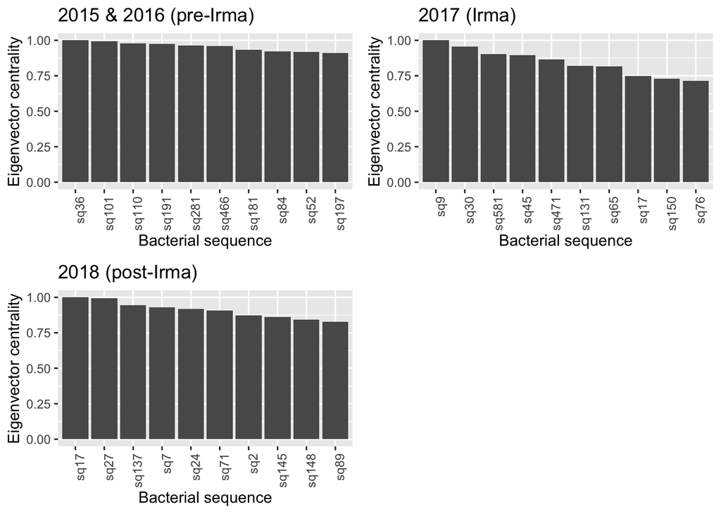

```r
eigen.1516 <- eigen_centrality(net_1516)
eigen.1516.tosort <- data.frame(eigen.1516[["vector"]])
eigen.1516.tosort$vector <- eigen.1516.tosort$eigen.1516...vector...
eigen.1516.sorted <- eigen.1516.tosort[order(-eigen.1516.tosort$vector),]
eigen.1516.sorted$sqs <- rownames(eigen.1516.sorted)
eigen.1516.top10 <- eigen.1516.sorted[1:10,]
sqs_order <- eigen.1516.top10$sqs
eigen.1516.top10$sqs <- factor(eigen.1516.top10$sqs,levels=sqs_order)
gg.eig.1516 <- ggplot(eigen.1516.top10,aes(x=sqs,y=vector))+
  geom_bar(stat="identity")+
  theme(axis.text.x=element_text(angle=90,hjust=1))+
  ylab("Eigenvector centrality")+
  xlab("Bacterial sequence")+
  ggtitle("2015 & 2016 (pre-Irma)")

eigen.17 <- eigen_centrality(net_17)
eigen.17.tosort <- data.frame(eigen.17[["vector"]])
eigen.17.tosort$vector <- eigen.17.tosort$eigen.17...vector...
eigen.17.sorted <- eigen.17.tosort[order(-eigen.17.tosort$vector),]
eigen.17.sorted$sqs <- rownames(eigen.17.sorted)
eigen.17.top10 <- eigen.17.sorted[1:10,]
sqs_order <- eigen.17.top10$sqs
eigen.17.top10$sqs <- factor(eigen.17.top10$sqs,levels=sqs_order)
gg.eig.17 <- ggplot(eigen.17.top10,aes(x=sqs,y=vector))+
  geom_bar(stat="identity")+
  theme(axis.text.x=element_text(angle=90,hjust=1))+
  ylab("Eigenvector centrality")+
  xlab("Bacterial sequence")+
  ggtitle("2017 (Irma)")

eigen.18 <- eigen_centrality(net_18)
eigen.18.tosort <- data.frame(eigen.18[["vector"]])
eigen.18.tosort$vector <- eigen.18.tosort$eigen.18...vector...
eigen.18.sorted <- eigen.18.tosort[order(-eigen.18.tosort$vector),]
eigen.18.sorted$sqs <- rownames(eigen.18.sorted)
eigen.18.top10 <- eigen.18.sorted[1:10,]
sqs_order <- eigen.18.top10$sqs
eigen.18.top10$sqs <- factor(eigen.18.top10$sqs,levels=sqs_order)
gg.eig.18 <- ggplot(eigen.18.top10,aes(x=sqs,y=vector))+
  geom_bar(stat="identity")+
  theme(axis.text.x=element_text(angle=90,hjust=1))+
  ylab("Eigenvector centrality")+
  xlab("Bacterial sequence")+
  ggtitle("2018 (post-Irma)")

ggarrange(gg.eig.1516,gg.eig.17,gg.eig.18)
```

Two important takeaways: 1. It looks like no two bacteria (‘sqs’ on the x-axis) are the most central nodes across all three timepoints 2. Steepest drop in eigen centrality during the 2017 timepoint - during Hurricane Irma!

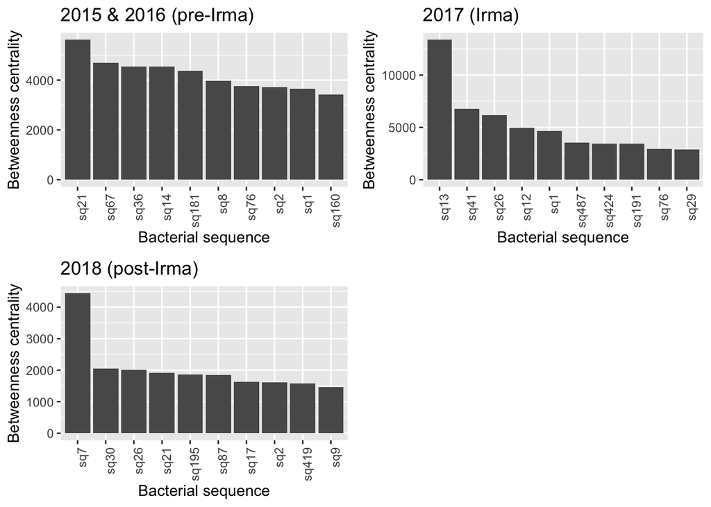

```r
btwn.1516.tosort <- data.frame(betweenness(net_1516))
btwn.1516.tosort$vector <- btwn.1516.tosort$betweenness.net_1516.
btwn.1516.sorted <- btwn.1516.tosort[order(-btwn.1516.tosort$vector),]
btwn.1516.sorted$sqs <- rownames(btwn.1516.sorted)
btwn.1516.top10 <- btwn.1516.sorted[1:10,]
sqs_order <- btwn.1516.top10$sqs
btwn.1516.top10$sqs <- factor(btwn.1516.top10$sqs,levels=sqs_order)
gg.btwn.1516 <- ggplot(btwn.1516.top10,aes(x=sqs,y=vector))+
  geom_bar(stat="identity")+
  theme(axis.text.x=element_text(angle=90,hjust=1))+
  ylab("Betweenness centrality")+
  xlab("Bacterial sequence")+
  ggtitle("2015 & 2016 (pre-Irma)")

btwn.17.tosort <- data.frame(betweenness(net_17))
btwn.17.tosort$vector <- btwn.17.tosort$betweenness.net_17.
btwn.17.sorted <- btwn.17.tosort[order(-btwn.17.tosort$vector),]
btwn.17.sorted$sqs <- rownames(btwn.17.sorted)
btwn.17.top10 <- btwn.17.sorted[1:10,]
sqs_order <- btwn.17.top10$sqs
btwn.17.top10$sqs <- factor(btwn.17.top10$sqs,levels=sqs_order)
gg.btwn.17 <- ggplot(btwn.17.top10,aes(x=sqs,y=vector))+
  geom_bar(stat="identity")+
  theme(axis.text.x=element_text(angle=90,hjust=1))+
  ylab("Betweenness centrality")+
  xlab("Bacterial sequence")+
  ggtitle("2017 (Irma)")

btwn.18.tosort <- data.frame(betweenness(net_18))
btwn.18.tosort$vector <- btwn.18.tosort$betweenness.net_18.
btwn.18.sorted <- btwn.18.tosort[order(-btwn.18.tosort$vector),]
btwn.18.sorted$sqs <- rownames(btwn.18.sorted)
btwn.18.top10 <- btwn.18.sorted[1:10,]
sqs_order <- btwn.18.top10$sqs
btwn.18.top10$sqs <- factor(btwn.18.top10$sqs,levels=sqs_order)
gg.btwn.18 <- ggplot(btwn.18.top10,aes(x=sqs,y=vector))+
  geom_bar(stat="identity")+
  theme(axis.text.x=element_text(angle=90,hjust=1))+
  ylab("Betweenness centrality")+
  xlab("Bacterial sequence")+
  ggtitle("2018 (post-Irma)")

ggarrange(gg.btwn.1516,gg.btwn.17,gg.btwn.18)
```

Similar pattern as in the eigenvector centrality plots

Left to do: - More metric analysis & all the statistics!